# Análise Fatorial

## Análise Fatorial

- **Objetivo:** Descrever as relações de covariância entre muitas variáveis em termos de poucas quantidades aleatórias subjacentes e não observáveis
- **Motivação:** Variáveis de um grupo altamente correlacionadas entre si, mas com pequenas correlações de outros grupos.
  - É concebível que cada grupo de variáveis represente um fator (ou construto) que seja o responsável pelas correlações observadas

## Análise Fatorial

Vamos supor cinco variáveis $Y_1$, $Y_2$, $Y_3$, $Y_4$ e $Y_5$ correspondentes às notas de estudantes em Espanhol, Inglês, Química, Física e Matemática, respectivamente.

Table 1: Matriz de correlações hipotética

|  | $Y_1$ | $Y_2$ | $Y_3$ | $Y_4$ | $Y_5$ |
| --- | --- | --- | --- | --- | --- |
| $Y_1$ | 1 | 0,90 | 0,05 | 0,05 | 0,10 |
| $Y_2$ | 0,90 | 1 | 0,05 | 0,10 | 0,05 |
| $Y_3$ | 0,05 | 0,05 | 1 | 0,95 | 0,85 |
| $Y_4$ | 0,05 | 0,10 | 0,95 | 1 | 0,90 |
| $Y_5$ | 0,10 | 0,05 | 0,85 | 0,90 | 1 |

## Análise Fatorial

Com base nas correlações, poderíamos imaginar dois fatores subjacentes, e não observáveis:

- **Fator 1:** Conhecimento em línguas - associado aos desempenhos em Espanhol e Inglês, fortemente correlacionados;
- **Fator 2:** Conhecimento em ciências exatas - associado aos desempenhos em Química, Física e Matemática.

É importante compreender que “conhecimento” é algo que não se mede diretamente, mas que pode se manifestar através de variáveis observáveis, como as notas obtidas nos exames.

## Análise Fatorial

Pode ser considerada uma extensão da Análise de Componentes Principais

- Ambas são tentativas de aproximar $\boldsymbol{S}$.
- A aproximação baseada em Análise Fatorial é mais elaborada

Questão principal:

- Dados são consistentes com a estrutura prescrita?

## Tipos de Análise Fatorial

### Análise Fatorial Exploratória

- Busca encontrar os fatores subjacentes às variáveis originais amostradas
- Em geral, efetuada quando não se tem noção clara da quantidade de fatores do modelo e nem do que representam

### Análise Fatorial Confirmatória

- Tem-se em mãos um modelo fatorial pré-especificado (modelo hipotético) e deseja-se verificar se é aplicável ou consistente com os dados amostrais de que dispõe

## Planejamento de uma análise fatorial

- **Verificar a adequabilidade da base de dados:** tamanho da amostra (desejável a razão de 5 indivíduos para cada variável), correlações significativas, KMO adequado.
- **Determinar o método de extração e o número de fatores a serem extraídos:** métodos de extração (componentes principais, fatores principais, máxima verossimilhança), número de fatores (critério de kaiser, screeplot, variância acumulada).
- **Decidir o tipo de rotação:** Varimax, Quartimax, Orthomax…

## Planejamento de uma análise fatorial

### GIGO: Garbage In, Garbage Out!

**Cuidado!**

- A análise fatorial sempre produzirá fatores. Desta forma, ela é sempre um candidato para o fenômeno **“lixo dentro, lixo fora”**.
- Se o pesquisador incluir indiscriminadamente um grande número de variáveis e esperar que a análise fatorial “faça revelações”, a possibilidade de resultados pobres será alta.
- A qualidade e o significado dos fatores determinados refletem **estruturas conceituais** das variáveis incluídas na análise (base conceitual).

## Planejamento de uma análise fatorial

### Questões conceituais…

- É responsabilidade do pesquisador garantir que os padrões observados sejam conceitualmente válidos. A AF é capaz somente de determinar a adequação das correlações entre variáveis.
- O pesquisador deve garantir que a amostra esteja adequada à estrutura fatorial inerente.
- Por exemplo, ao avaliar os fatores de risco de uma acidente vascular, se nenhuma variável relacionada aos fatores genéticos for incluída, a AF não será capaz de identificar esta dimensão.

## Planejamento de uma análise fatorial

### Questões conceituais…

- A qualidade e o significado dos fatores obtidos refletem as bases conceituais das variáveis incluídas na análise.
- O pesquisador não deve incluir indiscriminadamente inúmeras variáveis e esperar que a AF “arrume as coisas”.
- No exemplo da avaliação dos fatores de risco de uma acidente vascular, incluir a variável, por exemplo, “cor dos olhos” interfere nos resultados da AF e não traz nenhuma informação relevante para o objeto de estudo.

## Planejamento de uma análise fatorial

### Questões estatísticas…

- Espera-se que haja correlações significativas, pois o objetivo é identificar conjuntos de variáveis inter-relacionadas.
- Se todas as correlações são pequenas ou iguais, o pesquisador deve questionar o uso da análise fatorial.
- Inspeção visual da matriz de correlação – coeficientes pelo menos em torno de 0,30.

## Planejamento de uma análise fatorial

- **Teste de esfericidade de Bartlett (BTS):** O teste de esfericidade de Bartlett testa a hipótese de que as variáveis não sejam correlacionadas na população.

$$H_0: \boldsymbol{P} = \boldsymbol{I}$$

A estatística do teste é dada por

$$\chi^2 = -\left[ (n-1)-\dfrac{2p + 5}{6}\right] \ln|\boldsymbol{R}|$$

que tem uma distribuição qui-quadrado com $\nu$ graus de liberdade, sendo $\nu = \dfrac{p(p-1)}{2}$, $n$ igual ao tamanho da amostra, $p$ igual ao número de variáveis e $|\boldsymbol{R}|$, o determinante da matriz de correlação amostral.

## Planejamento de uma análise fatorial

- **Medida de adequação da amostra:** comumente utilizado o KMO (Kaiser-Meyer-Olkin). Rencher(2002) sugere que para um modelo de Análise Fatorial possa ser ajustado adequadamente aos dados é necessário que $\boldsymbol{R}^{-1}$ seja próxima da matriz diagonal. O coeficiente KMO baseia-se nesse princípio

$$KMO = \dfrac{\displaystyle{\sum_{i=1}^p}\displaystyle{\sum_{j=1}^p} r^2_{ij}}{\displaystyle{\sum_{i=1}^p}\displaystyle{\sum_{j=1}^p} r_{ij}^2 + \displaystyle{\sum_{i=1}^p}\displaystyle{\sum_{j=1}^p}v_{ij}^2},$$

## Planejamento de uma análise fatorial

em que $r_{ij}$ e $v_{ij}$ são, respectivamente, os elementos na posição $(i,j)$ da matriz de correlações amostral, $\boldsymbol{R}$, e da matriz $\boldsymbol{V} = \boldsymbol{U} \boldsymbol{R}^{-1} \boldsymbol{U}$, na qual $\boldsymbol{U} = \left[{\rm diag} (\boldsymbol{R}^{-1})^{\frac{1}{2}}\right]^{-1}$. Note que ${\rm diag}(\boldsymbol{R}^{-1})$ é a matriz cuja diagonal coincide com a diagonal de $\boldsymbol{R}^{-1}$ mas com os demais elementos nulos e ${\rm diag}(\boldsymbol{R}^{-1})^{\frac{1}{2}}$ é a matriz diagonal cujo $i$-ésimo elemento diagonal é a raiz quadrada do $i$-ésimo elemento diagonal de ${\rm diag}(\boldsymbol{R}^{-1})$. A matriz $\boldsymbol{V}$ é usualmente designada por matriz de correlação anti-imagem.

## Planejamento de uma análise fatorial

- **Medida de adequação da amostra:** Para cada variável: MSA (Measure of sampling adequacy). Essa medida é bastante similar ao $KMO$. Novamente, desejamos verificar a possibilidade de existência de uma estrutura fatorial nos dados. A $MSA$ deve ser calculada separadamente para cada variável, através de

$$MSA_i = \dfrac{\displaystyle{\sum_{j=1}^p} r^2_{ij}}{\displaystyle{\sum_{j=1}^p} r_{ij}^2 + \displaystyle{\sum_{j=1}^p}v_{ij}^2}.$$

## Planejamento de uma análise fatorial

- O objetivo é verificar se uma dada variável pode ser explicada pelas demais, o que é esperado em um modelo fatorial.
- Valores baixos de $MSA_i$ são indícios de que a respectiva variável pode ser retirada da análise, sem maiores prejuízos.
- Note que esta medida é bastante similar ao $KMO$, apresentando uma lógica semelhante.

## Planejamento de uma análise fatorial

Ambos variam de 0 a 1, sendo:

Table 2: Tabela de interpretação do índice KMO/MSA

| KMO/MSA | Interpretação |
| --- | --- |
| $0,80 - 1,00$ | Excelente |
| $0,70 - 0,80$ | Ótimo |
| $0,60 - 0,70$ | Bom |
| $0,50 - 0,60$ | Regular |
| $0,00 - 0,50$ | Insuficiente |

## O modelo fatorial ortogonal via matriz de correlações

- Seja o vetor aleatório $\mathbf{x} = [X_1, X_2, \cdots, X_p]^t$, com vetor de médias $\boldsymbol{\mu}$, matriz de covariâncias $\boldsymbol{\Sigma}$ e matriz de correlações $\boldsymbol{P}$.
- Sejam as variáveis originais padronizadas: $Z_i = \dfrac{X_i - \mu_i}{\sqrt{\sigma_{ii}}}$
- $\boldsymbol{P}$ é a matriz de covariâncias do velor aleatório $\boldsymbol{z}$, cujas componentes são as variáveis padronizadas.

## O modelo fatorial ortogonal via matriz de correlações

- Modelo fatorial ortogonal
  - Construído via a matriz de correlação populacional
  - Relaciona linearmente as variáveis padronizadas e os $m$ fatores comuns (que são desconhecidos)
  - Fatores são variáveis independentes

## O modelo fatorial ortogonal via matriz de correlações

Na análise fatorial, vamos expressar cada uma das $p$ variáveis padronizadas como combinação linear de $m < p$ fatores comuns $F_1, F_2, \cdots, F_m$ a menos de um termo correspondente ao erro $\epsilon_1, \epsilon_2, \cdots, \epsilon_p$:

$$\begin{aligned}
Z_1 &= l_{11}F_1 + l_{12}F_2 + \cdots + l_{1m}F_m + \epsilon_1 \\
Z_2 &= l_{21}F_1 + l_{22}F_2 + \cdots + l_{2m}F_m + \epsilon_2 \\ && \hspace{-25cm} \vdots \\
Z_p &= l_{p1}F_1 + l_{p2}F_2 + \cdots + l_{pm}F_m + \epsilon_p
\end{aligned}$$

## O modelo fatorial ortogonal

- $F_1, F_2, \cdots, F_m$ são os fatores comuns **não observáveis**, ou (*latentes*);
- $\epsilon_1, \epsilon_2, \cdots,\epsilon_p$ são os fatores específicos associados a cada variável e,
- $l_{ij}$, $i = 1, 2, \cdots,p$, $j = 1, 2, \cdots, m$ são chamados de cargas fatoriais, ou (*loadings*).

## O modelo fatorial ortogonal

### Notação Matricial

$$\boxed{\boldsymbol{D}^{-1}(\mathbf{x} - \boldsymbol{\mu}) = \boldsymbol{L} \boldsymbol{F} + \boldsymbol{\epsilon}}$$

$$\boldsymbol{F} = \left[\begin{array}{c} F_1 \\ F_2 \\ \vdots \\ F_m \end{array} \right] \boldsymbol{\epsilon} =
\left[\begin{array}{c} \epsilon_1 \\ \epsilon_2 \\ \vdots \\ \epsilon_p \end{array}\right]
\boldsymbol{L} = \left[ \begin{array}{cccc} l_{11} & l_{12} & \cdots & l_{1m}
\\ l_{21} & l_{22} & \cdots & l_{2m}
\\ \vdots & \vdots & \ddots & \vdots
\\ l_{p1} & l_{p2} & \cdots & l_{pm}
\end{array} \right] \,\,\, \boldsymbol{D} = \left[ \begin{array}{cccc} \sigma_{1} & 0 & \cdots & 0
\\ 0 & \sigma_{2} & \cdots & 0
\\ \vdots & \vdots & \ddots & \vdots
\\ 0 & 0 & \cdots & \sigma_{p}
\end{array} \right]$$

## O modelo fatorial ortogonal

### Suposições do modelo

Para construção do modelo fatorial ortogonal, algumas suposições se fazem necessárias:

1. Os fatores têm média igual a zero, variâncias iguais a 1 e não são correlacionados:

$$\boxed{E({\boldsymbol{F}}) = \boldsymbol{0}\,\, \text{e} \,\, \rm{Var}({\boldsymbol{F}}) = E({\boldsymbol{F}}{\boldsymbol{F}}^t) = \boldsymbol{I} }$$

## O modelo fatorial ortogonal

### Suposições do modelo

2. Os erros têm média zero, são não correlacionados e não necessariamente tem a mesma variância:

$$\boxed{E({\boldsymbol{\epsilon}}) = \boldsymbol{0} e \rm{Var}({\boldsymbol{\epsilon}}) = \boldsymbol{\Psi} = \rm{diag}(\psi_1, \psi_2, \cdots, \psi_p)
= E({\boldsymbol{\epsilon}}{\boldsymbol{\epsilon}}^t)
}$$

3. ${\boldsymbol{F}}$ e ${\boldsymbol{\epsilon}}$ são independentes, isto é, fontes de variação distintas:

$$\boxed{\rm{Cov}({\boldsymbol{F}},{\boldsymbol{\epsilon}}) = E({\boldsymbol{\epsilon}}{\boldsymbol{F}}^t) = \boldsymbol{0}}$$

## Propriedades do modelo fatorial

Como consequência da definição do modelo e das suposições apresentadas, decorrem as seguintes propriedades:

$$\boldsymbol{P} = \boldsymbol{L}\boldsymbol{L}^t + \boldsymbol{\Psi}$$

- Esta decomposição implica que as variâncias das variáveis observadas podem ser escritas como:

$$\text{Var}(Z_i) = \underbrace{l_{i1}^2 + l_{i2}^2 + \cdots + l_{im}^2}_{h_i^2} + \psi_i = h_i^2 + \psi_i, \hspace{0.5cm} i = 1, \cdots, p$$

## Propriedades do modelo fatorial

- $h_i^2$ é a **comunalidade:** variância comum de $\boldsymbol{z}$ - expressa o quanto da variabiliade de $Z_i$ é explicada pelo modelo
- $\psi_i$ é a **especificidade:** variância específica de cada $Z_i$ - expressa o quanto da variabilidade de $Z_i$ não é explicada pelo modelo.

Além disso, as covariâncias das variáveis observadas podem ser escritas como:

$$\text{Cov}(Z_i, Z_k) = {l_{i1}l_{k1} + l_{i2}l_{k2} + \cdots + l_{im}l_{km}}, \,\,\, i,k = 1, \cdots, p \,\,(i\neq k)$$

e,

$$\text{Cov}(\boldsymbol{z}, \boldsymbol{F}) = \text{Cor}(\boldsymbol{z}, \boldsymbol{F}) = \boldsymbol{L}$$

## Métodos de Estimação

- **Método das componentes principais:** baseia-se na análise de componentes principais. Em geral, utilizado como um análise exploratória dos dados, em termos dos fatores subjacentes
- **Método dos fatores principais:** refina a solução apresentada pelo método das componentes principais
- **Método da máxima verossimilhança:** supõe que os dados seguem uma distribuição normal multivariada

## Métodos de estimação: Componentes Principais

Considerando $m < p$ o número de fatores comuns, a matriz de cargas fatoriais, estimada pelo método dos componentes principais, fica dada por:

$$\begin{aligned}
\hat{\boldsymbol{L}} &= \left[\begin{array}{cccc} \sqrt{\hat{\lambda}}_1 \hat{\boldsymbol{e}}_1 & \sqrt{\hat{\lambda}}_2 \hat{\boldsymbol{e}}_2 & \cdots & \sqrt{\hat{\lambda}}_m \hat{\boldsymbol{e}}_m \end{array}\right]
\end{aligned}$$

E a matriz de especificidades é dada por:

$$\hat{\boldsymbol{\Psi}} = \rm{diag}(\boldsymbol{R} - \hat{\boldsymbol{L}} \hat{\boldsymbol{L}}^t)$$

Aproximação de $\boldsymbol{R}$

$$\boldsymbol{R} \approx \hat{\boldsymbol{L}} \hat{\boldsymbol{L}}^t + \hat{\boldsymbol{\Psi}}$$

## Métodos de estimação: Componentes Principais

Matriz residual:

$$\boldsymbol{MRes} = \boldsymbol{R} - (\hat{\boldsymbol{L}} \hat{\boldsymbol{L}}^t + \hat{\boldsymbol{\Psi}})$$

- Pode servir como critério de avaliação do modelo
  - Seus valores deveriam ser próximos de zero
  - Matriz é nula somente quando o valor de $m$ é igual a $p$
- Os elementos da diagonal da matriz $\boldsymbol{R}$ são reproduzidos exatamente pelo modelo
  - O mesmo não ocorre para os outros elementos da matriz $\boldsymbol{R}$ (covariâncias das variáveis $Z_i$ e $Z_j$)

## Métodos de estimação: Componentes Principais

Proporção da variabilidade total explicada pelo fator

$$\text{Proporção explicada}_{F_j} = \dfrac{\sum \limits_{i=1}^p l_{ij}^2}{p}$$

- Representa o quanto cada fator consegue captar da variabilidade original das variáveis $Z_i$.

## Métodos de estimação: Fatores Principais

- Também chamado Método de Componentes Principais Iterativo
- **Ideia básica:** Refinar as estimativas de $\hat{\boldsymbol{L}}$ e $\hat{\boldsymbol{\Psi}}$, encontradas a partir do método das componentes principais.
- **Procedimento:**
  - Estimativas iniciais pelo método das componentes principais
  - Troca dos elementos da diagonal de $\boldsymbol{R}$ pelas comunalidades estimadas
  - Novas estimações a partir da matriz $\boldsymbol{R}^*$
  - Substituição dos elementos da diagonal principal pelas comunalidades estimadas
  - Procedimento é repetido até que as diferenças entres as comunalidades estimadas sejam desprezíveis

## Métodos de estimação: Máxima Verossimilhança

Só pode ser utilizado quando a forma da distribuição de probabilidades é conhecida

- **Suposição:**
  - Vetor aleatório $\boldsymbol{z}$ tem distribuição normal $p$-variada
- **Consequência:**
  - Vetor das variáveis padronizadas é normal $p$-variado
  - Fatores tem distribuição normal multivariada com vetor de médias zero e matriz de covariâncias $\boldsymbol{I}_m$
  - Erros tem distribuição normal $p$-variada com vetor de médias zero e matriz de covariâncias $\boldsymbol{\Psi}$.

## Métodos de estimação: Máxima Verossimilhança

A função de verossimilhança considerando uma amostra aleatória de tamanho $n$ observada no vetor aleatório $\boldsymbol{z}$ é dada por:

$$\boldsymbol{L}(\boldsymbol{0},\boldsymbol{P}) = \displaystyle \frac{1}{(2\pi)^{\frac{np}{2}} |(\boldsymbol{L} \boldsymbol{L}^t + \boldsymbol{\Psi})|^{\frac{n}{2}}} \exp \left\{-\frac{1}{2} \displaystyle \sum_{j=1}^n \boldsymbol{z}_j^t (\boldsymbol{L}\boldsymbol{L}^t + \boldsymbol{\Psi})^{-1} \boldsymbol{z}_j \right\}$$

- A função de verossimilhança depende da matrizes $\boldsymbol{L}$ e $\boldsymbol{\Psi}$, através da matriz de correlação $\boldsymbol{P}$.

## Métodos de estimação: Máxima Verossimilhança

- Os estimadores de máxima verossimilhança de $\boldsymbol{L}$ e $\boldsymbol{\Psi}$ são as matrizes $\hat{\boldsymbol{L}}$ e $\hat{\boldsymbol{\Psi}}$ que **maximizam** a função de verossimilhança $\boldsymbol{L}(\boldsymbol{0},\boldsymbol{P})$.
- Maximização é feita por métodos numéricos.
- Método mais sofisticado que os métodos de componentes e fatores principais: produz estimativas mais precisas

## Métodos de estimação: Máxima Verossimilhança

**Cuidado!**

- Está fundamentado na suposição de normalidade multivariada dos vetores $\boldsymbol{z}$, $\boldsymbol{F}$ e $\boldsymbol{\epsilon}$.
  - Apenas a normalidade do vetor $\boldsymbol{z}$ pode ser investigada a priori a partir dos dados amostrais
  - Fatores e erros são variáveis aleatórias não observáveis

**Observação Importante**

- O método de estimação por Máxima Verossimilhança (ML) pode ser utilizado na Análise Fatorial mesmo quando os dados não seguem uma distribuição normal multivariada. A falta de normalidade afeta principalmente os testes de significância ($\chi^2$, $IC$), mas não compromete a qualidade da extração dos fatores. ML é robusto para escalas Likert com 5 ou mais categorias.

## Rotação dos fatores

Uma propriedade importante do modelo fatorial ortogonal é a **falta de unicidade das cargas fatoriais:** se $\boldsymbol{L}$ satisfaz à relação $\boldsymbol{P} = \boldsymbol{L}\boldsymbol{L}^t + \boldsymbol{\Psi}$, então $\boldsymbol{L}^* = \boldsymbol{L} \boldsymbol{T}$, tal que $\boldsymbol{T} \boldsymbol{T}^t = \boldsymbol{T}^t\boldsymbol{T} = \boldsymbol{I}$ ($\boldsymbol{T}$ ortogonal), também satisfaz:

$$\begin{aligned}
\boldsymbol{L}^* \boldsymbol{L}^{*t} + \boldsymbol{\Psi} &= (\boldsymbol{L} \boldsymbol{T})(\boldsymbol{L} \boldsymbol{T})^t + \boldsymbol{\Psi} = \boldsymbol{L} \boldsymbol{T}\boldsymbol{T}^t \boldsymbol{L}^t + \boldsymbol{\Psi} \\ &= \boldsymbol{L} \boldsymbol{I} \boldsymbol{L}^t + \boldsymbol{\Psi} =
\boldsymbol{L}\boldsymbol{L}^t + \boldsymbol{\Psi } = \boldsymbol{P}
\end{aligned}$$

A matriz de resíduos permanece a mesma ($\hat{h}_i^2$ e $\hat{\Psi}_i$)

$$\boldsymbol{R} - \hat{\boldsymbol{L}} \hat{\boldsymbol{L}}^t - \hat{\boldsymbol{\Psi}} = \boldsymbol{R} - \hat{\boldsymbol{L}}^* \hat{\boldsymbol{L}}^{*t} - \hat{\boldsymbol{\Psi}}$$

- Do ponto de vista estatístico é irrelevante obter $\hat{\boldsymbol{L}}$ ou $\hat{\boldsymbol{L}}^*$

## Rotação dos fatores

Ao rotacionar a matriz fatorial, busca-se redistribuir a variância dos primeiros fatores para os últimos, a fim de atingir um padrão fatorial mais simples e teoricamente mais significativo.

Table 3: Cargas fatoriais dos dois fatores extraídos

[output not shown]

## Rotação dos fatores

$$\text{ 2 agrupamentos: As cargas fatoriais, contudo, não parecem tão óbvias}$$

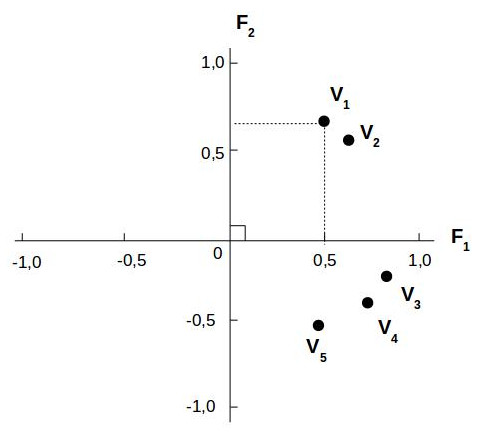

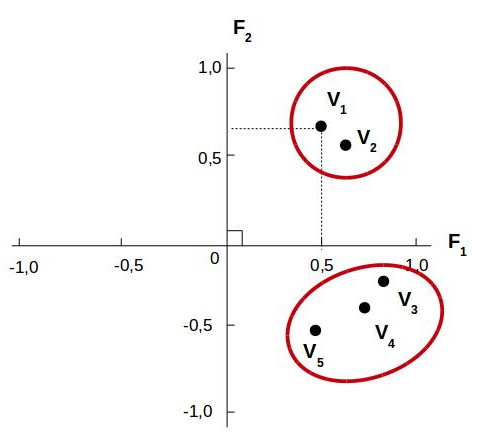

## Rotação dos fatores

$$\text{Rotação Ortogonal}$$

Table 4: Cargas fatoriais estimadas para dois fatores

| Variáveis | Fator 01 | Fator 02 |
| --- | --- | --- |
| $V_1$ | $0,03$ | $0,90$ |
| $V_2$ | $0,19$ | $0,82$ |
| $V_3$ | $0,95$ | $0,22$ |
| $V_4$ | $0,89$ | $0,12$ |
| $V_5$ | $0,78$ | $-0,12$ |

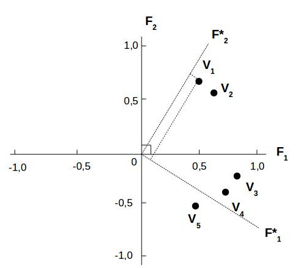

## Rotação dos fatores

- Os métodos de rotação têm como objetivo simplificar as linhas e colunas da matriz fatorial para facilitar a interpretação
  - Maximizar a carga de uma variável em um único fator
  - Reduzir ao máximo o número de variáveis com cargas altas por fator
- Alguns critérios para encontrar matriz ortogonal:
  - Varimax
  - Quartimax
  - Orthomax

## Rotação dos fatores

- **Critério Varimax:** É um dos mais utilizados. Em geral, produz soluções mais simples
- **Critério Quartimax:** Tem tendência de gerar fatores, onde todas as variáveis têm loadings elevados
- **Critério Orthomax:** É uma média ponderada dos dois outros métodos

## Rotação dos fatores

### Comentários

- **Qualidade de ajuste:** A rotação não acrescenta nenhuma melhoria em relação ao ajuste original
  - Matriz residual original não é alterada pela transformação ortogonal
  - Valores estimados de comunalidade e variâncias específicas permanecem inalterados
- **Interpretação:** Novos fatores podem ser de mais fácil interpretação
- Quando a solução sem rotação já é de boa qualidade, não se recomenda rotação: Solução rotacionada pode ser pior

## Quantos fatores usar?

Para determinar o valor de $m$…

- Analisar a proporção da variação total dos dados atribuída ao $j$-ésimo fator, dada por:

$$\dfrac{\hat{\lambda}_j}{p}, \,\,\,\, j = 1,2, \cdots, m, \text{ se usarmos } \boldsymbol{R}$$

- **Critério de Kaiser:** retenção dos fatores com autovalor associado superior a 1;
- Gráfico scree-plot
- Análise paralela de Horn

## Quantos fatores usar?

- Conjugar indicadores estatísticos a:
  - Interpretação prática dos resultados;
  - Busca de uma solução parcimoniosa;
  - Possível indicação do número de fatores segundo a teoria da área;
- **Bom senso (sempre!)**.

## Quantos fatores usar?

### Comentários

- **Método de máxima verossimilhança:** Mudança de valor de $m$ altera as estimativas dos loadings
- **Método de componentes principais:** Aumento no valor de $m$ não altera os loadings para os fatores obtidos anteriormente
- Quando os dados provêm de distribuição normal multivariada
  - Usar método de componentes principais como análise exploratória dos fatores e estimação do valor provável de $m$
  - Posteriormente, qualidade da solução inicial poderá ser melhorada pelo uso do método de máxima verossimilhança

## Interpretação dos fatores

$$\text{Avaliação da significância estatística baseada no tamanho da amostra}$$

Tamanho mínimo de amostra recomendado em função da carga fatorial

| Carga Fatorial | Tamanho da amostra |
| --- | --- |
| 0,30 | 350 |
| 0,35 | 250 |
| 0,40 | 200 |
| 0,45 | 150 |
| 0,50 | 120 |
| 0,55 | 100 |
| 0,60 | 85 |
| 0,65 | 70 |
| 0,70 | 60 |
| 0,75 | 50 |

## Interpretação dos fatores

$$\text{Interpretação de uma matriz de cargas fatoriais em 5 passos}$$

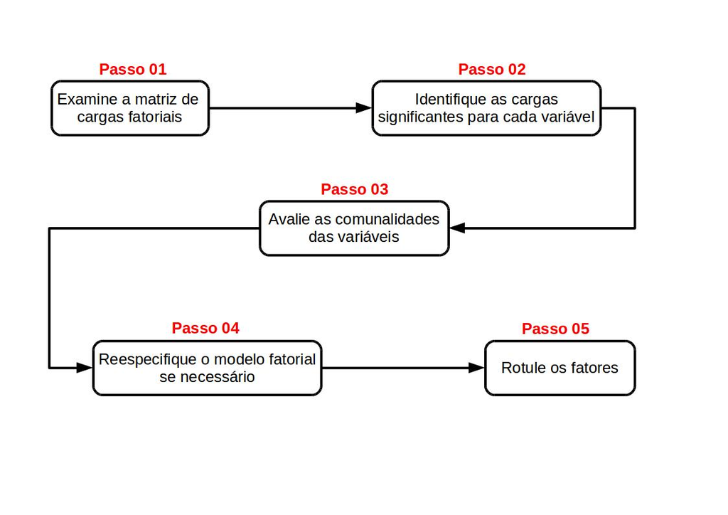

## Interpretação dos fatores

$$\text{Algumas situações podem ser encontradas}$$

$$\textbf{A variável tem carga cruzada}$$

| **Variável** | **Fator 01** | **Fator 02** | **Comunalidade** |
| --- | --- | --- | --- |
| $\cdots$ | $\cdots$ | $\cdots$ | $\cdots$ |
| $V_i$ | $-0,64$ | $-0,56$ | $0,72$ |
| $\cdots$ | $\cdots$ | $\cdots$ | $\cdots$ |

## Interpretação dos fatores

$$\text{Algumas situações podem ser encontradas}$$

$$\textbf{A variável não possui cargas significantes}$$

| **Variável** | **Fator 01** | **Fator 02** | **Comunalidade** |
| --- | --- | --- | --- |
| $\cdots$ | $\cdots$ | $\cdots$ | $\cdots$ |
| $V_i$ | $-0,25$ | $0,19$ | $0,10$ |
| $\cdots$ | $\cdots$ | $\cdots$ | $\cdots$ |

## Interpretação dos fatores

$$\text{Algumas situações podem ser encontradas}$$

$$\textbf{Mesmo com cargas significantes, a comunalidade é baixa}$$

| **Variável** | **Fator 01** | **Fator 02** | **Comunalidade** |
| --- | --- | --- | --- |
| $\cdots$ | $\cdots$ | $\cdots$ | $\cdots$ |
| $V_i$ | 0,00 | 0,40 | 0,16 |
| $\cdots$ | $\cdots$ | $\cdots$ | $\cdots$ |

## Interpretação dos fatores

$$\text{Alternativas}$$

- **Ignorar as variáveis problemáticas** e interpretar a solução fatorial como ela é, observando que as variáveis em questão são pobremente representadas na solução fatorial;
- Avaliar cada variável para uma **possível eliminação** e reespecificar o modelo após sua retirada;
- Empregar um **método alternativo de rotação**;
- **Diminuir/aumentar o número de fatores** para avaliar se a nova estrutura fatorial representará as variáveis problemáticas;

## Comentários finais sobre análise fatorial

- **Matriz de resíduos:** A observação da matriz de resíduos muitas vezes, pode indicar quando o número de fatores está superdimensionado
  - Ex.: Se $m$ não for muito pequeno e a matriz de resíduos estiver próxima de zero, recomenda-se testar outras soluções para $m$ menores que o valor já especificado
- A análise fatorial deve ser utilizada apenas se utilizada em situações em que as variáveis originais são correlacionadas: Evitar soluções com $m$ elevado tal que determinados fatores fiquem relacionados com uma única variável original
- Em situações em que aparecem fatores relacionados a uma única variável $Z_i$ é recomendável retirar a variável $Z_i$ e reestimar o modelo de análise fatorial

## Usos adicionais dos resultados da AFE

$$\textbf{Como posso usar os resultados de uma AFE em análises subsequentes?}$$

- Seleção de variáveis substitutas para análise subseqüente
  - É selecionada a variável com maior carga no fator para atuar como **variável substituta representativa** (deve considerar o conhecimento que o pesquisador tem da teoria).
- **Escores Fatoriais:** representação de cada indivíduo no espaço fatorial. A estimação dos escores fatoriais necessita de métodos estatíscos elaborados, sendo os mais conhecidos os métodos da regressão e dos mínimos quadrados ponderados.

## Escores fatoriais

- **Método dos Mínimos Quadrados Ponderados:**

$$\hat{\boldsymbol{f}} = ( \hat{\boldsymbol{L}}^t \hat{\boldsymbol{\Psi}}^{-1} \hat{\boldsymbol{L}})^{-1} \hat{\boldsymbol{L}}^t \hat{\boldsymbol{\Psi}}^{-1} \boldsymbol{z}$$

- **Método da Regressão:** suposição de normalidade multivariada para $\boldsymbol{z}$, $\boldsymbol{F}$ e $\boldsymbol{\epsilon}$

$$\hat{\boldsymbol{f}} = \hat{\boldsymbol{L}}^t (\hat{\boldsymbol{L}} \hat{\boldsymbol{L}}^t + \hat{\boldsymbol{\Psi}})^{-1}\boldsymbol{z}$$

## Contexto: empresa Telco

- Operadora de telefonia móvel em cidade do interior
- Pesquisa de satisfação com os clientes após um ano de operação
- Questionário com **10 itens (P1–P10)** em escala de 0 a 10

## Contexto: empresa Telco

Os itens avaliam, por exemplo:

- Intensidade do sinal
- Qualidade do serviço e das informações
- Justiça nas tarifas
- Distribuição geográfica do sinal
- Plano de serviços
- Desconfiança em relação à empresa
- Tecnologia, atenção e atendimento

## Itens e variáveis

Vamos representar os 10 itens por variáveis $X_1, \ldots, X_{10}$:

- $X_1$: intensidade do sinal
- $X_2$: distribuição geográfica do sinal
- $X_3$: tecnologia adotada
- $X_4$: atendimento como um todo
- $X_5$: injustiça nas tarifas
- $X_6$: plano de serviços
- $X_7$: qualidade das informações
- $X_8$: serviço prestado ao cliente
- $X_9$: atenção dedicada ao cliente
- $X_{10}$: atendimento especificamente ao cliente

## Objetivo da análise

**Objetivo:** **identificar dimensões latentes** da qualidade percebida.

```r
# Instale o pacote pacman primeiro, se ainda não o tiver
if (!requireNamespace("pacman", quietly = TRUE)) {
  install.packages("pacman")
}

# Use p_load para instalar e carregar pacotes
pacman::p_load(tidyverse, psych, GPArotation, ggcorrplot, janitor, corrr, igraph, ggraph, ggrepel)
```

## Lendo os dados Telco

```r
path <- "https://raw.githubusercontent.com/tiagomartin/est014/refs/heads/master/dados/telco.csv"
telco <- read_csv(path, show_col_types = FALSE) %>%
  clean_names()

glimpse(telco)
```

```
Rows: 875
Columns: 10
$ x1  <dbl> 2.021634, 2.634654, 2.161853, 2.611833, 2.296529, 2.265094, 2.7789…
$ x2  <dbl> 3.417002, 4.989637, 4.369748, 5.058855, 2.652786, 4.401388, 5.0625…
$ x3  <dbl> 3.203575, 3.548522, 3.423754, 3.438870, 3.394790, 3.446864, 3.4617…
$ x4  <dbl> 4.674381, 5.167249, 5.076795, 5.145240, 4.935702, 4.960152, 5.0267…
$ x5  <dbl> 7.845196, 7.527241, 7.432190, 7.381899, 7.572431, 7.401869, 7.3539…
$ x6  <dbl> 4.474652, 5.155799, 4.955571, 5.005566, 4.857968, 4.987190, 5.0357…
$ x7  <dbl> 1.652540, 2.303569, 3.000841, 3.084402, 2.834656, 4.363538, 4.4467…
$ x8  <dbl> 3.192175, 3.652853, 4.442697, 4.541976, 4.221692, 4.371027, 4.4521…
$ x9  <dbl> 7.092796, 7.518412, 6.690318, 6.761366, 6.098145, 6.766362, 6.8473…
$ x10 <dbl> 2.882242, 3.046624, 3.350822, 3.388591, 3.197836, 3.273597, 3.3047…
```

```r
dim(telco)
```

```
[1] 875  10
```

## Matriz de correlação

```r
R <- cor(telco, use = "pairwise.complete.obs")
R
```

```
               x1            x2            x3            x4            x5
x1   1.0000000000  0.4781493696  0.7589493789 -2.140846e-03  0.0053772224
x2   0.4781493696  1.0000000000  0.5673144741 -6.145747e-03  0.0072963197
x3   0.7589493789  0.5673144741  1.0000000000 -5.368382e-04  0.0047779539
x4  -0.0021408464 -0.0061457470 -0.0005368382  1.000000e+00 -0.5773156240
x5   0.0053772224  0.0072963197  0.0047779539 -5.773156e-01  1.0000000000
x6   0.5414366524  0.4011884586  0.6425555030  7.028403e-01 -0.4256035677
x7   0.0014174056 -0.0011068157  0.0020693251  5.251678e-01 -0.3252902914
x8   0.0075964582  0.0028010661  0.0011511906  7.496806e-03 -0.0041722500
x9   0.0001745702  0.0013298066  0.0008497782 -3.530898e-03 -0.0026125521
x10  0.0067917792  0.0001410227  0.0044244904  3.148538e-05  0.0004600118
              x6            x7           x8            x9           x10
x1   0.541436652  0.0014174056  0.007596458  0.0001745702  6.791779e-03
x2   0.401188459 -0.0011068157  0.002801066  0.0013298066  1.410227e-04
x3   0.642555503  0.0020693251  0.001151191  0.0008497782  4.424490e-03
x4   0.702840339  0.5251677868  0.007496806 -0.0035308985  3.148538e-05
x5  -0.425603568 -0.3252902914 -0.004172250 -0.0026125521  4.600118e-04
x6   1.000000000  0.3942750794  0.008252132 -0.0023037351  3.223454e-03
x7   0.394275079  1.0000000000  0.004857482 -0.0009232318  1.151786e-03
x8   0.008252132  0.0048574820  1.000000000 -0.7925700049  5.324280e-01
x9  -0.002303735 -0.0009232318 -0.792570005  1.0000000000 -4.301518e-01
x10  0.003223454  0.0011517859  0.532427996 -0.4301518161  1.000000e+00
```

## Visualização da matriz de correlação

```r
ggcorrplot(
R,
type = "full",
lab = TRUE,
title = "Matriz de correlação – Itens Telco"
)
```

```r
# Blocos de correlações altas sugerem possíveis fatores latentes
```

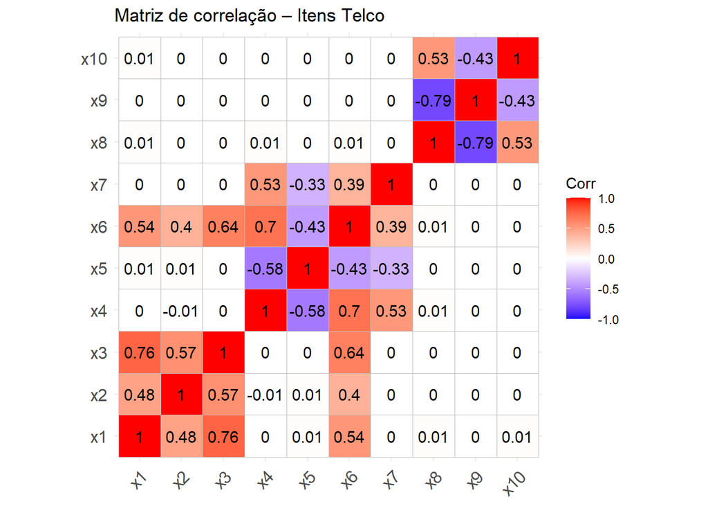

## Visualização da matriz de correlação

```r
## Variaveis aparentam se agrupar em tres grupos
tidy_cors <- telco %>% correlate() %>% stretch()
graph_cors <- tidy_cors %>%  filter(abs(r) > .3) %>% graph_from_data_frame(directed = FALSE)
ggraph(graph_cors, layout = "stress") +
  geom_edge_link(alpha = 0.5) +
  geom_node_point(size = 4) +
  geom_node_text(aes(label = name), repel = TRUE, size = 5) +
  theme_minimal()
```

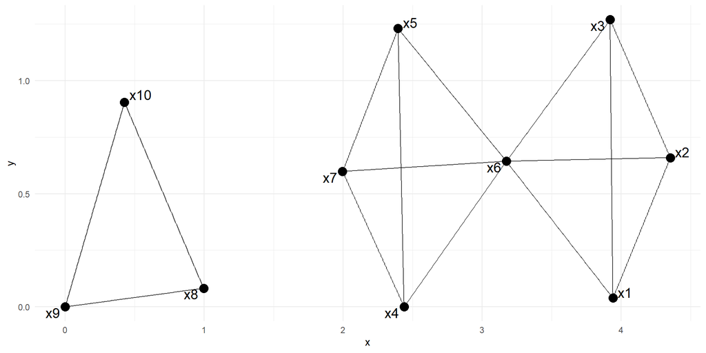

## Medidas de adequação à AFE

### KMO – Kaiser-Meyer-Olkin

```r
KMO(R)
```

```
Kaiser-Meyer-Olkin factor adequacy
Call: KMO(r = R)
Overall MSA =  0.63
MSA for each item =
  x1   x2   x3   x4   x5   x6   x7   x8   x9  x10
0.85 0.93 0.56 0.46 0.93 0.55 0.94 0.58 0.60 0.79
```

- KMO geral > 0,60 → dados adequados para AFE
- MSA de $X_4 < 0,5$ → apresenta adequabilidade insuficiente, podendo ser retirada da analise

## Medidas de adequação à AFE

### Teste de esfericidade de Bartlett

```r
cortest.bartlett(R, n = nrow(telco))
```

```
$chisq
[1] 5049.455

$p.value
[1] 0

$df
[1] 45
```

- p-valor de Bartlett < 0,05 → correlações não são nulas

## Escolha do número de fatores: Parallel Analysis

```r
set.seed(123)

fa.parallel(
telco,
fm = "ml",
fa = "fa",
main = "Parallel Analysis – Caso Telco"
)
```

```
Parallel analysis suggests that the number of factors =  3  and the number of components =  NA
```

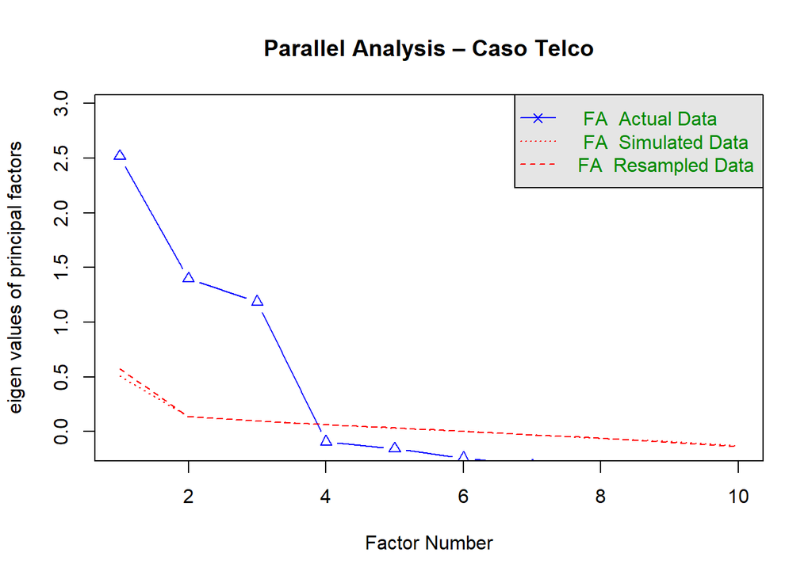

## Escolha do número de fatores: Parallel Analysis

- Comparamos autovalores observados com autovalores obtidos ao acaso.
- Mantemos os fatores com autovalores acima da linha simulada.

```r
n_fatores <- 3
```

## Ajuste da AFE

```r
fa_telco <- factanal(
  x        = telco,
  factors  = n_fatores,
  rotation = "none",
  scores   = "none"
)

print(fa_telco, digits = 3, cut = 0.30) # n = 875: cargas acima de 0,30 sao significativas
```

```
Call:
factanal(x = telco, factors = n_fatores, scores = "none", rotation = "none")

Uniquenesses:
   x1    x2    x3    x4    x5    x6    x7    x8    x9   x10
0.359 0.642 0.101 0.056 0.647 0.016 0.707 0.019 0.360 0.711

Loadings:
    Factor1 Factor2 Factor3
x1   0.514           0.614
x2   0.380           0.462
x3   0.610           0.726
x4   0.743          -0.626
x5  -0.451           0.387
x6   0.990
x7   0.416          -0.346
x8           0.990
x9          -0.800
x10          0.537

               Factor1 Factor2 Factor3
SS loadings      2.691   1.910   1.780
Proportion Var   0.269   0.191   0.178
Cumulative Var   0.269   0.460   0.638

Test of the hypothesis that 3 factors are sufficient.
The chi square statistic is 0.32 on 18 degrees of freedom.
The p-value is 1
```

```r
# Podemos notar que os 3 fatores explicam juntos 63,8% da variacao total do sistema original
```

## Ajuste da AFE

**Analisando as cargas significativas**

- $X_1$ - Apresenta cargas cruzadas - fatores 01 e 03 - $h^2$: 0,641 - MSA: 0,85
- $X_2$ - Apresenta cargas cruzadas - fatores 01 e 03 - $h^2$: 0,358 - MSA: 0,93
- $X_3$ - Apresenta cargas cruzadas - fatores 01 e 03 - $h^2$: 0,899 - MSA: 0,56
- $X_4$ - Apresenta cargas cruzadas - fatores 01 e 03 - $h^2$: 0,944 - MSA: 0,46
- $X_5$ - Apresenta cargas cruzadas - fatores 01 e 03 - $h^2$: 0,353 - MSA: 0,93
- $X_6$ - fator 01 - $h^2$: 0,984 - MSA: 0,55
- $X_7$ - Apresenta cargas cruzadas - fatores 01 e 03 - $h^2$: 0,293 - MSA: 0,94
- $X_8$ - fator 02 - $h^2$: 0,981 - MSA: 0,58
- $X_9$ - fator 02 - $h^2$: 0,640 - MSA: 0,60
- $X_{10}$ - fator 02 - $h^2$: 0,289 - MSA: 0,79

## Vamos em busca de uma solucao melhor: rotacao Varimax()

```r
varimax(fa_telco$loadings)
```

```
$loadings

Loadings:
    Factor1 Factor2 Factor3
x1                   0.801
x2                   0.598
x3                   0.948
x4   0.971
x5  -0.594
x6   0.729           0.673
x7   0.541
x8           0.991
x9          -0.800
x10          0.538

               Factor1 Factor2 Factor3
SS loadings      2.121   1.910   2.350
Proportion Var   0.212   0.191   0.235
Cumulative Var   0.212   0.403   0.638

$rotmat
            [,1]        [,2]        [,3]
[1,]  0.76987948 0.025103554  0.63769538
[2,] -0.01744908 0.999680498 -0.01828749
[3,] -0.63795072 0.002951969  0.77007153
```

```r
# Note que a proporcao total da variacao explicada pelos 3 fatores nao muda (63,8%). O que muda eh a proporcao da variacao total explicada por cada fator
```

## Rotação Varimax()

**Analisando novamente as cargas significativas**

- $X_1$ - fator 03
- $X_2$ - fator 03
- $X_3$ - fator 03
- $X_4$ - fator 01
- $X_5$ - fator 01
- $X_6$ - Apresenta cargas cruzadas - fatores 01 e 03 - $h^2$: 0,984 - MSA: 0,55
- $X_7$ - fator 01
- $X_8$ - fator 02
- $X_9$ - fator 02
- $X_{10}$ - fator 02

## Segunda tentativa: excluir da analise a variavel $X_4$ (MSA inadequado)

```r
telco2 <- telco %>% select(-x4)

fa_telco2 <- factanal(
  x        = telco2,
  factors  = n_fatores,
  rotation = "varimax",
  scores   = "none"
)

print(fa_telco2, digits = 3, cut = 0.30) # n = 875: cargas acima de 0,30 sao significativas
```

```
Call:
factanal(x = telco2, factors = n_fatores, scores = "none", rotation = "varimax")

Uniquenesses:
   x1    x2    x3    x5    x6    x7    x8    x9   x10
0.360 0.642 0.101 0.644 0.023 0.702 0.019 0.360 0.711

Loadings:
    Factor1 Factor2 Factor3
x1   0.800
x2   0.598
x3   0.948
x5                  -0.596
x6   0.662           0.734
x7                   0.546
x8           0.991
x9          -0.800
x10          0.537

               Factor1 Factor2 Factor3
SS loadings      2.335   1.910   1.193
Proportion Var   0.259   0.212   0.133
Cumulative Var   0.259   0.472   0.604

Test of the hypothesis that 3 factors are sufficient.
The chi square statistic is 0.23 on 12 degrees of freedom.
The p-value is 1
```

```r
# Podemos notar que os 3 fatores explicam juntos 60,4% da variacao total do sistema original e não resolveu o problema
```

## Terceira tentativa: voltar para a análise a variável $X_4$ e retirar a variável $X_6$

```r
telco3 <- telco %>% select(-x6)

fa_telco3 <- factanal(
  x        = telco3,
  factors  = n_fatores,
  rotation = "none",
  scores   = "Bartlett"
)

print(fa_telco3, digits = 3, cut = 0.30) # n = 875: cargas acima de 0,30 sao significativas
```

```
Call:
factanal(x = telco3, factors = n_fatores, scores = "Bartlett",     rotation = "none")

Uniquenesses:
   x1    x2    x3    x4    x5    x7    x8    x9   x10
0.360 0.643 0.100 0.068 0.642 0.704 0.019 0.360 0.711

Loadings:
    Factor1 Factor2 Factor3
x1           0.800
x2           0.598
x3           0.949
x4                   0.965
x5                  -0.598
x7                   0.544
x8   0.991
x9  -0.800
x10  0.537

               Factor1 Factor2 Factor3
SS loadings      1.911   1.897   1.586
Proportion Var   0.212   0.211   0.176
Cumulative Var   0.212   0.423   0.599

Test of the hypothesis that 3 factors are sufficient.
The chi square statistic is 0.24 on 12 degrees of freedom.
The p-value is 1
```

```r
# Podemos notar que os 3 fatores explicam juntos 59,9% da variacao total do sistema original
```

## Solução final excluindo $X_6$ da análise

- **Fator 01:** associado a $X_8$, $X_9$ e $X_{10}$
  - **Interpretação:** dimensão relacionada a atendimento / relacionamento com o cliente
- **Fator 02:** associado a $X_1$, $X_2$ e $X_3$
  - **Interpretação:** dimensão de qualidade técnica / infraestrutura (sinal, distribuição, tecnologia)
- **Fator 03:** associado a $X_4$, $X_5$ e $X_7$
  - **Interpretação:** dimensão de plano, informações e justiça tarifária

## Solução final excluindo $X_6$ da análise

```r
loadings_nr <- fa_telco3$loadings |>
unclass() |>
as.data.frame() |>
rownames_to_column("item")

ggplot(loadings_nr, aes(x = Factor1, y = Factor2, label = item)) +
geom_hline(yintercept = 0, linetype = "dashed", color = "grey70") +
geom_vline(xintercept = 0, linetype = "dashed", color = "grey70") +
geom_point(size = 3) +
geom_text_repel(size = 5) +
labs(
title = "Mapa das cargas não rotacionadas – Fator 1 × Fator 2",
x = "Factor 1",
y = "Factor 2"
) +
theme_minimal(base_size = 14)
```

## Solução final excluindo $X_6$ da análise

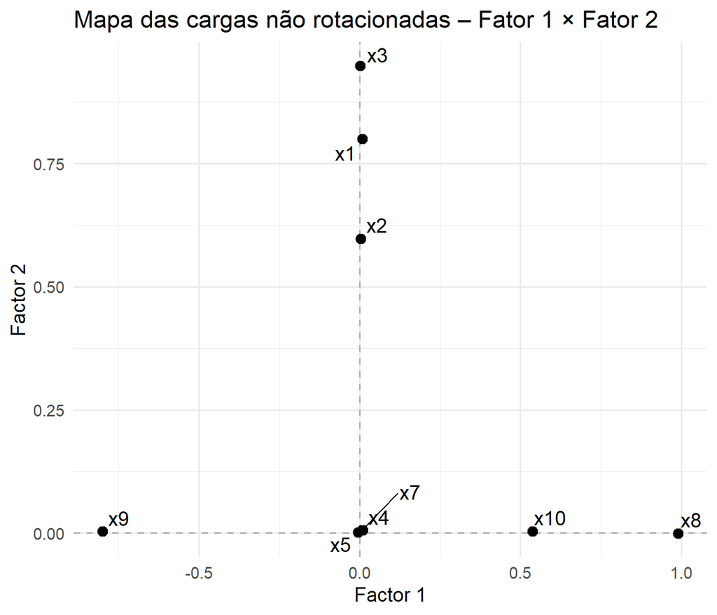

## Solução final excluindo $X_6$ da análise

**Pontos a destacar:**

- Proporção da variabilidade explicada por cada fator
  - **Fator 1:** cerca de 21%
  - **Fator 2:** cerca de 21%
  - **Fator 3:** cerca de 18%
- Proporção da variabilidade explicada pelo modelo ≈ 0.60:
- A solução de 3 fatores explica aproximadamente 60% da variância total das variáveis padronizadas.
- Para um estudo com itens de questionário (escala de 0 a 10), essa proporção é considerada muito boa.